# Reproducible Research: Peer Assessment 1

Haron Shihab

Thursday, August 14, 2014

## Loading and processing the data

1. Load the data

```r
activity <- read.csv("activity.csv")
```

2. Process/transform the date vatiable in the data to actual date class in R

```r
activity$date <- as.Date(activity$date)
```

### What is mean total number of steps taken per day?

For this part of the assignment, you can ignore the missing values in the dataset.

1. Make a histogram of the total number of steps taken each day

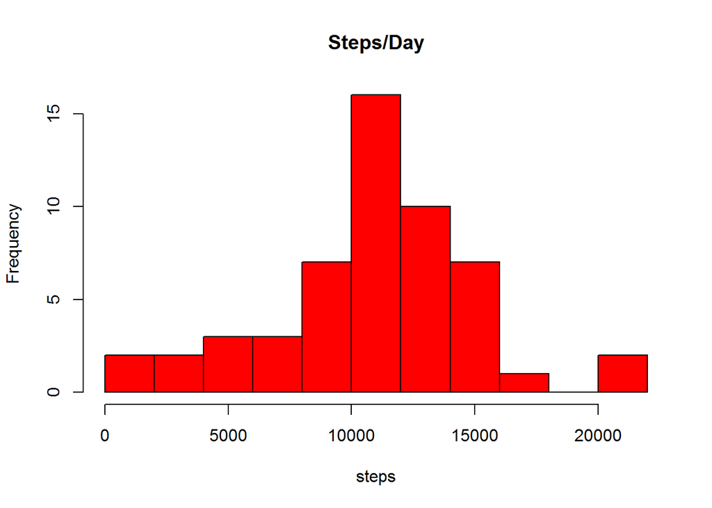

```r
day.steps <- tapply(activity$steps, activity$date, sum)
hist(day.steps, breaks = 10, col = "red", xlab = "steps", main = "Steps/Day")
```

2. Calculate and report the mean and median total number of steps taken per day

```r
mean(day.steps, na.rm = T)
median(day.steps, na.rm = T)
```

mean = 1.0766 × 10<sup>4</sup> and median = 10765

### What is the average daily activity pattern?

1. Make a time series plot (i.e. `type = "l"`) of the 5-minute interval (x-axis) and the average number of steps taken, averaged across all days (y-axis)

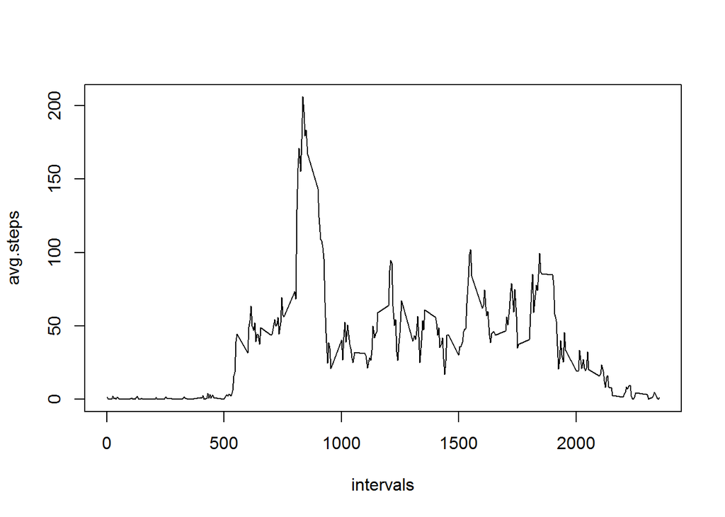

```r
avg.steps <- tapply(activity$steps, activity$interval, mean, na.rm = T)

#get the numeric vector representing the levels of the 5-min intervals
intervals <- as.numeric(levels(factor(activity$interval)))
plot(intervals, avg.steps, type = "l")
```

2. Which 5-minute interval, on average across all the days in the dataset, contains the maximum number of steps?

```r
intervals[avg.steps == max(avg.steps)]
```

Maximum number of steps is in interval 835